# Covid-19 SEIR modeling with POMP

Mehrdad

Dec 2021

# Prerequisites

We start by loading the required packages and setting up the parameters for our optimization.

```r
library(latex2exp)
library(foreach)
library(doParallel)
options(warn=-1)
# numCores <- commandArgs(trailingOnly=TRUE)[1]
# numCores <- as.numeric(numCores) - 1
numCores = 1
registerDoParallel(cores=numCores)
# print(paste('number of cores is ',numCores, ' for YV'))

library(doRNG)
registerDoRNG(625904618)
library(tidyverse)
library(pomp)
options(stringsAsFactors=FALSE)
stopifnot(packageVersion("pomp")>="3.0")

# We define three run levels. 1 can be used for diagnostic and 3 is used for actual optimizations
run_level <- 3
covid_Np <-          switch(run_level,100, 1e3, 2e4)
covid_Nmif <-        switch(run_level, 10, 100, 100)
covid_Nreps_eval <-  switch(run_level,  2,  10,  10)
covid_Nreps_local <- switch(run_level, 10,  10,  10)
covid_Nreps_global <-switch(run_level, 10,  20,  20)
covid_Nsim <-        switch(run_level, 50, 100, 100)
```

# Model Components Specifications

We now define the pomp model components including process model, measurement model, initial states, parameters and parameters' transformations.

### Process Model

```r
#########################################################################
#--------------------------|  rproc  |----------------------------------#
#########################################################################
rproc <- Csnippet("
                  double beta, foi, dw, births, mu_SE;

                  //we only consider those that participate in the epidemic:
                  double pop = S + E + I + R;

                  // transmission rate
                  beta = b0;

                  // expected force of infection. iota: imported infections
                  // alpha mixing parameter, = 1:homogeneous mixing
                  foi = beta*pow(I+iota, alpha)/pop;

                  // white noise (extrademographic stochasticity)
                  dw = rgammawn(sigmaSE,dt);

                  mu_SE = foi*dw/dt;  // stochastic force of infection

                  // Poisson births: fraction of leak into S from N
                  births = rpois(br*dt);


                  // State Updates:
                  double dN_SE  = rbinom(S , 1-exp(-mu_SE  *dt));
                  double dN_EI  = rbinom(E , 1-exp(-mu_EI  *dt));
                  double dN_IR  = rbinom(I , 1-exp(-mu_IR *dt));
                  S += births - dN_SE;
                  E += dN_SE  - dN_EI;
                  I += dN_EI  - dN_IR;
                  R += dN_IR;
                  W += (dw - dt)/sigmaSE;  // standardized i.i.d. white noise
                  ")
```

### Inital Distribution

```r
#########################################################################
#--------------------------|  rinit  |----------------------------------#
#########################################################################
rinit <- Csnippet("
                  double m = eta*N;
                  S = nearbyint(m*S_0);
                  E = nearbyint(m*E_0);
                  I = nearbyint(m*I_0);
                  R = nearbyint(m*R_0);
                  W = 0;
                  ")
```

### Measurement Model

#### SEIR-VY

```r
#########################################################################
#--------------------------|  dmeas  |----------------------------------#
#########################################################################
dmeas_VY <- Csnippet("
                  // Model for Viral Load
                  double shed_cases = E + I;
                  double mu_V = rho_V*shed_cases;
                  //double std_V = sqrt(mu_V*(1+od_V));
                  double lik_V = dnorm(V, mu_V, sd_V, 1);

                  // Model for Case Counts
                  double mu_Y = rho_Y*I;
                  double std_Y = sqrt(mu_Y*(1+od_Y));
                  double lik_Y;

                  if (Y > 0.0) {
                  lik_Y = pnorm(Y+0.5,mu_Y,std_Y,1,1)
                  - pnorm(Y-0.5,mu_Y,std_Y,1,1);
                  } else {
                  lik_Y = pnorm(Y+0.5,mu_Y,std_Y,1,1);
                  }

                  // Combined likelihood
                  lik = lik_V + lik_Y;
                  //lik = lik_V;
                  //lik = lik_Y;
                  lik = (give_log) ? lik : exp(lik);

                  ")

#########################################################################
#--------------------------|  rmeas  |----------------------------------#
#########################################################################
rmeas_VY <- Csnippet("
                  // Viral Load
                  double shed_cases = E + I;
                  double mu_V = rho_V*shed_cases;
                  //double std_V = sqrt(mu_V*(1+od_V));
                  V = rnorm(mu_V, sd_V);

                  // Case Counts
                  double mu_Y = rho_Y*I;
                  double std_Y = sqrt(mu_Y*(1+od_Y));
                  Y = rnorm(mu_Y, std_Y);
                  if (Y > 0.0) {
                  Y = nearbyint(Y);
                  } else {
                  Y = 0.0;
                  }

                  ")
```

#### SEIR-V

```r
#########################################################################
#--------------------------|  dmeas  |----------------------------------#
#########################################################################
dmeas_V <- Csnippet("
                  // Model for Viral Load
                  double shed_cases = E + I;
                  double mu_V = rho_V*shed_cases;
                  //double std_V = sqrt(mu_V*(1+od_V));
                  double lik_V = dnorm(V, mu_V, sd_V, 1);

                  // Model for Case Counts
                  double mu_Y = rho_Y*I;
                  double std_Y = sqrt(mu_Y*(1+od_Y));
                  double lik_Y;

                  if (Y > 0.0) {
                  lik_Y = pnorm(Y+0.5,mu_Y,std_Y,1,1)
                  - pnorm(Y-0.5,mu_Y,std_Y,1,1);
                  } else {
                  lik_Y = pnorm(Y+0.5,mu_Y,std_Y,1,1);
                  }

                  // Combined likelihood
                  //lik = lik_V + lik_Y;
                  lik = lik_V;
                  //lik = lik_Y;
                  lik = (give_log) ? lik : exp(lik);

                  ")

#########################################################################
#--------------------------|  rmeas  |----------------------------------#
#########################################################################
rmeas_V <- Csnippet("
                  // Viral Load
                  double shed_cases = E + I;
                  double mu_V = rho_V*shed_cases;
                  //double std_V = sqrt(mu_V*(1+od_V));
                  V = rnorm(mu_V, sd_V);

                  // Case Counts
                  double mu_Y = rho_Y*I;
                  double std_Y = sqrt(mu_Y*(1+od_Y));
                  Y = rnorm(mu_Y, std_Y);
                  if (Y > 0.0) {
                  Y = nearbyint(Y);
                  } else {
                  Y = 0.0;
                  }

                  ")
```

#### SEIR-Y

```r
#########################################################################
#--------------------------|  dmeas  |----------------------------------#
#########################################################################
dmeas_Y <- Csnippet("
                  // Model for Viral Load
                  double shed_cases = E + I;
                  double mu_V = rho_V*shed_cases;
                  //double std_V = sqrt(mu_V*(1+od_V));
                  double lik_V = dnorm(V, mu_V, sd_V, 1);

                  // Model for Case Counts
                  double mu_Y = rho_Y*I;
                  double std_Y = sqrt(mu_Y*(1+od_Y));
                  double lik_Y;

                  if (Y > 0.0) {
                  lik_Y = pnorm(Y+0.5,mu_Y,std_Y,1,1)
                  - pnorm(Y-0.5,mu_Y,std_Y,1,1);
                  } else {
                  lik_Y = pnorm(Y+0.5,mu_Y,std_Y,1,1);
                  }

                  // Combined likelihood
                  //lik = lik_V + lik_Y;
                  //lik = lik_V;
                  lik = lik_Y;
                  lik = (give_log) ? lik : exp(lik);

                  ")

#########################################################################
#--------------------------|  rmeas  |----------------------------------#
#########################################################################
rmeas_Y <- Csnippet("
                  // Viral Load
                  double shed_cases = E + I;
                  double mu_V = rho_V*shed_cases;
                  //double std_V = sqrt(mu_V*(1+od_V));
                  V = rnorm(mu_V, sd_V);

                  // Case Counts
                  double mu_Y = rho_Y*I;
                  double std_Y = sqrt(mu_Y*(1+od_Y));
                  Y = rnorm(mu_Y, std_Y);
                  if (Y > 0.0) {
                  Y = nearbyint(Y);
                  } else {
                  Y = 0.0;
                  }

                  ")
```

### Parameters

```r
#########################################################################
#-------------------------|  Parameters  |------------------------------#
#########################################################################
parameters = c(
  "b0", "alpha", "iota",
  "sigmaSE",
  "br",
  "mu_EI", "mu_IR",
  "N",
  "eta",
  "rho_V", "sd_V",
  "rho_Y", "od_Y",
  "S_0","E_0","I_0", "R_0")


par_trans = parameter_trans(
  log = c(
    "b0", "alpha", "iota","sigmaSE", "br",
    "rho_V", "sd_V", "od_Y"),
  logit = c("mu_EI", "mu_IR","eta", "rho_Y"),
  barycentric=c("S_0","E_0","I_0", "R_0")
)
states = c("S", "E", "I", "R", "W")
```

# Data

Here we read our data. We then apply a delay of 5 days for the case counts (as discussed in the paper)

```r
data = read_csv("https://raw.githubusercontent.com/Shakeri-Lab/COVID-SEIR/main/Data/abm.csv")
#########################################################################
#-------------------------|  Covariates  |------------------------------#
#########################################################################

sdm_covar <- covariate_table(
  t=      data[["day"]],
  sdmm=   data[["sdm"]],
  event=  data[["events"]],
  order=  "constant",
  times=  "t"
)

# shifting case counts by the assumed reporting delay
rep_del = 5    # reporting delay
data %>% mutate_at(c("Y_1"),
                       tibble::lst("Y_1"=lead),
                       n=rep_del) %>%
  mutate_at(c("Y_2"),
            tibble::lst("Y_2"=lead),
            n=rep_del)%>%
  mutate_at(c("Y_3"),
            tibble::lst("Y_3"=lead),
            n=rep_del)%>%
  mutate_at(c("Y"),
            tibble::lst("Y"=lead),
            n=rep_del)-> data_c

# focusing on the first peak for now
data <- data_c[1:70,]
```

# pomp Model

Now that we have the model components along with the data, we can define our pomp model.

## SEIR-VY

```r
covidSEIRsR_VY = data %>%
  select(-logV) %>%
  rename(V = V,
         Y = Y
  ) %>%
  pomp(
    times = "day", # column name of data that corresponds to time
    t0 = 0,        # starting time
    # rprocess = discrete_time(rproc, delta.t=1), # daily
    rprocess = euler(rproc, delta.t=1/6), # every four
    rinit = rinit,
    rmeasure = rmeas_VY,
    dmeasure = dmeas_VY,
    accumvars= c("W"),
    partrans = par_trans,
    statenames = states,
    paramnames = parameters,
    covar=sdm_covar
  )
```

## SEIR-V

```r
covidSEIRsR_V = data %>%
  select(-logV) %>%
  rename(V = V,
         Y = Y
  ) %>%
  pomp(
    times = "day", # column name of data that corresponds to time
    t0 = 0,        # starting time
    # rprocess = discrete_time(rproc, delta.t=1), # daily
    rprocess = euler(rproc, delta.t=1/6), # every four
    rinit = rinit,
    rmeasure = rmeas_V,
    dmeasure = dmeas_V,
    accumvars= c("W"),
    partrans = par_trans,
    statenames = states,
    paramnames = parameters,
    covar=sdm_covar
  )
```

## SEIR-Y

```r
covidSEIRsR_Y = data %>%
  select(-logV) %>%
  rename(V = V,
         Y = Y
  ) %>%
  pomp(
    times = "day", # column name of data that corresponds to time
    t0 = 0,        # starting time
    # rprocess = discrete_time(rproc, delta.t=1), # daily
    rprocess = euler(rproc, delta.t=1/6), # every four
    rinit = rinit,
    rmeasure = rmeas_Y,
    dmeasure = dmeas_Y,
    accumvars= c("W"),
    partrans = par_trans,
    statenames = states,
    paramnames = parameters,
    covar=sdm_covar
  )
```

# Simulations

As a quick check of the model we run some simulations with a set of guess parameters.

## SEIR-VY

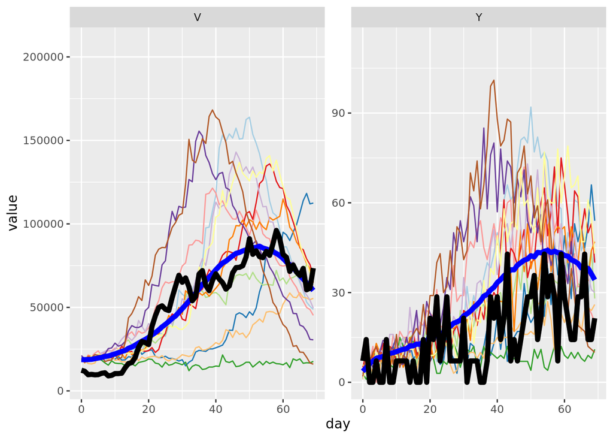

```r
params_guess = c(
  b0=0.013, alpha=1.62, iota=5,
  sigmaSE=0.8,
  br=2,
  mu_EI=.16, mu_IR=0.13, # state transition
  rho_V=150, sd_V=1000,                    # measurement V
  rho_Y=.14, od_Y=0,                   # measurement Y
  eta=.05, N=50000,                   # initial value parameters
  S_0=.95, E_0=.04, I_0=.01, R_0=.0)


y = covidSEIRsR_VY %>%
  simulate(params=params_guess, nsim=250, format="data.frame")

y_avg = y %>% group_by(day) %>% summarize_at(vars(S:R, V, Y), mean)


observed = data %>%
  mutate(actual.cases = Y / params_guess['rho_Y']) %>%
  select(day, V = V, Y = actual.cases) %>%
  pivot_longer(c(V, Y))

y %>% pivot_longer(c(V, Y)) %>%
  ggplot(aes(x = day, y = value)) +
  geom_line(aes(color = factor(.id))) +
  geom_line(data = y_avg %>% pivot_longer(c(V, Y)),
            size=2, color="blue") +
  geom_line(data = observed, color="black", size=2) +
  scale_color_brewer(type = 'qual', palette = 3) +
  guides(color = FALSE) +
  facet_wrap(~name, scales="free_y")
```

## SEIR-V

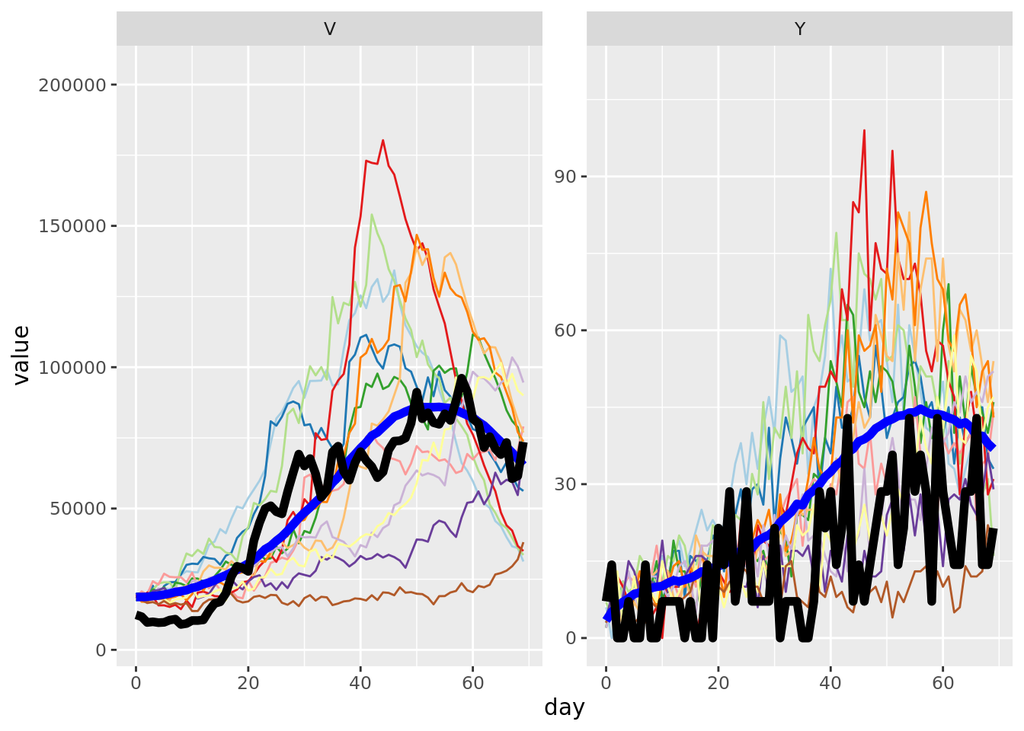

```r
params_guess = c(
  b0=0.013, alpha=1.62, iota=5,
  sigmaSE=0.8,
  br=2,
  mu_EI=.16, mu_IR=0.13, # state transition
  rho_V=150, sd_V=1000,                    # measurement V
  rho_Y=.14, od_Y=0,                   # measurement Y
  eta=.05, N=50000,                   # initial value parameters
  S_0=.95, E_0=.04, I_0=.01, R_0=.0)


y = covidSEIRsR_V %>%
  simulate(params=params_guess, nsim=250, format="data.frame")

y_avg = y %>% group_by(day) %>% summarize_at(vars(S:R, V, Y), mean)


observed = data %>%
  mutate(actual.cases = Y / params_guess['rho_Y']) %>%
  select(day, V = V, Y = actual.cases) %>%
  pivot_longer(c(V, Y))

y %>% pivot_longer(c(V, Y)) %>%
  ggplot(aes(x = day, y = value)) +
  geom_line(aes(color = factor(.id))) +
  geom_line(data = y_avg %>% pivot_longer(c(V, Y)),
            size=2, color="blue") +
  geom_line(data = observed, color="black", size=2) +
  scale_color_brewer(type = 'qual', palette = 3) +
  guides(color = FALSE) +
  facet_wrap(~name, scales="free_y")
```

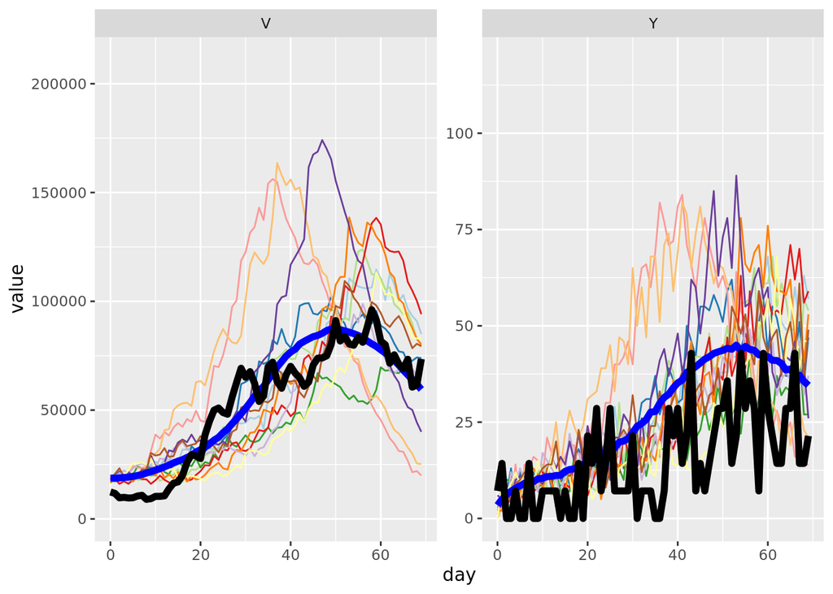

```r
params_guess = c(
  b0=0.013, alpha=1.62, iota=5,
  sigmaSE=0.8,
  br=2,
  mu_EI=.16, mu_IR=0.13, # state transition
  rho_V=150, sd_V=1000,                    # measurement V
  rho_Y=.14, od_Y=0,                   # measurement Y
  eta=.05, N=50000,                   # initial value parameters
  S_0=.95, E_0=.04, I_0=.01, R_0=.0)


y = covidSEIRsR_Y %>%
  simulate(params=params_guess, nsim=250, format="data.frame")

y_avg = y %>% group_by(day) %>% summarize_at(vars(S:R, V, Y), mean)


observed = data %>%
  mutate(actual.cases = Y / params_guess['rho_Y']) %>%
  select(day, V = V, Y = actual.cases) %>%
  pivot_longer(c(V, Y))

y %>% pivot_longer(c(V, Y)) %>%
  ggplot(aes(x = day, y = value)) +
  geom_line(aes(color = factor(.id))) +
  geom_line(data = y_avg %>% pivot_longer(c(V, Y)),
            size=2, color="blue") +
  geom_line(data = observed, color="black", size=2) +
  scale_color_brewer(type = 'qual', palette = 3) +
  guides(color = FALSE) +
  facet_wrap(~name, scales="free_y")
```

# Particle Filtering

As a secondary check we apply particle filter and make sure the our model is capable of filtering.

## SEIR-VY

```r
#########################################################################
#----------------------|  Particle Filtering  |-------------------------#
#########################################################################

tic <- Sys.time()

foreach(i=1:10,.combine=c) %dopar% {
  library(pomp)
  covidSEIRsR_VY %>% pfilter(params=params_guess,Np=5000)
} -> pf

pf %>% logLik() %>% logmeanexp(se=TRUE) -> L_pf
L_pf
```

```
##                        se
## -846.5972127    0.5133548
```

```r
toc <- Sys.time()
```

## SEIR-V

```r
#########################################################################
#----------------------|  Particle Filtering  |-------------------------#
#########################################################################

tic <- Sys.time()

foreach(i=1:10,.combine=c) %dopar% {
  library(pomp)
  covidSEIRsR_V %>% pfilter(params=params_guess,Np=5000)
} -> pf

pf %>% logLik() %>% logmeanexp(se=TRUE) -> L_pf
L_pf
```

```
##                    se
## -799.66973    1.86635
```

```r
toc <- Sys.time()
```

## SEIR-Y

```r
#########################################################################
#----------------------|  Particle Filtering  |-------------------------#
#########################################################################

tic <- Sys.time()

foreach(i=1:10,.combine=c) %dopar% {
  library(pomp)
  covidSEIRsR_Y %>% pfilter(params=params_guess,Np=5000)
} -> pf

pf %>% logLik() %>% logmeanexp(se=TRUE) -> L_pf
L_pf
```

[output not shown]

```r
toc <- Sys.time()
```

# Local Search

Finally and before we search the entire parameter space, we apply the iterated filtering on our guess parameters to see if the model is capable of increasing the log-likelihood.

## SEIR-VY

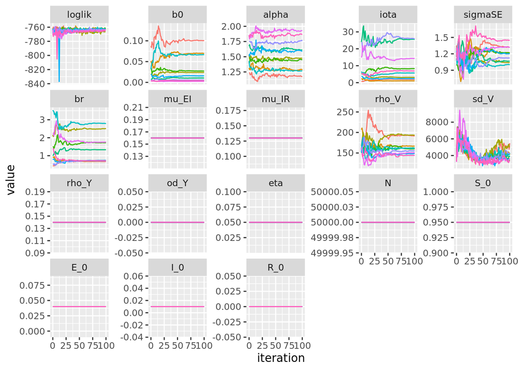

```r
#- Below is the code for the local search

# registerDoRNG(482947940)
# bake(file=paste(cache_address,"/local_search_simple_VY.rds", sep = ''),{
#   foreach(i=1:covid_Nreps_local,.combine=c, .errorhandling="remove") %dopar% {
#     library(pomp)
#     library(tidyverse)
#     covidSEIRsR %>%
#       mif2(
#         params=params_guess,
#         Np=covid_Np, Nmif=covid_Nmif,
#         cooling.fraction.50=0.5,
#         rw.sd=rw.sd(b0=0.02, alpha=0.02, iota=0.02,
#                     sigmaSE=0.02, br=0.01, mu_EI=0.00, mu_IR=0.00,
#                     S_0=ivp(0.00), E_0=ivp(0.00), I_0=ivp(0.00), R_0=ivp(0.00),
#                     eta=ivp(0.00), rho_V=0.01, rho_Y=0.0, sd_V=0.5, od_Y=0.0)
#       ) %>%
#       mif2(cooling.fraction.50=0.3) %>%
#       mif2(cooling.fraction.50=0.1)
#   } -> mifs_local
#   attr(mifs_local,"ncpu") <- getDoParWorkers()
#   mifs_local
# }) -> mifs_local
# t_loc <- attr(mifs_local,"system.time")
# ncpu_loc <- attr(mifs_local,"ncpu")

#- we just load the result of the local search

githubURL <- ("https://raw.githubusercontent.com/Shakeri-Lab/COVID-SEIR/main/res/local_search_simple_VY.rds")
download.file(githubURL,"local_search_simple_VY.rds")
mifs_local <- readRDS("local_search_simple_VY.rds")

mifs_local[[1]] -> SEIR_VY

#plotting the parallel tasks for the local search}
mifs_local %>%
  traces() %>%
  melt() %>%
  ggplot(aes(x=iteration, y=value, group=L1, color=factor(L1)))+
  geom_line()+
  guides(color=FALSE)+
  facet_wrap(~variable,scales="free_y")
```

## SEIR-V

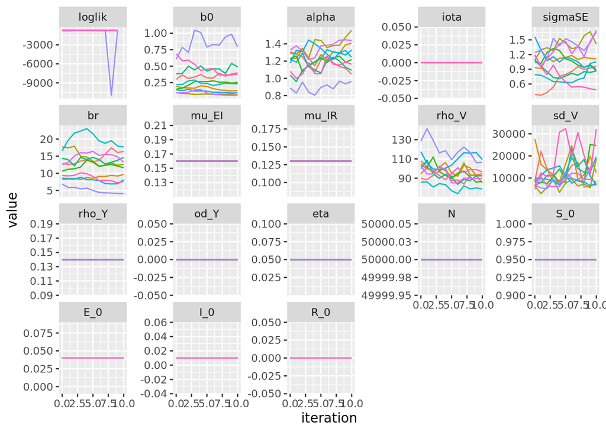

```r
#- Below is the code for the local search

# registerDoRNG(482947940)
# bake(file=paste(cache_address,"/local_search_simple_VY.rds", sep = ''),{
#   foreach(i=1:covid_Nreps_local,.combine=c, .errorhandling="remove") %dopar% {
#     library(pomp)
#     library(tidyverse)
#     covidSEIRsR %>%
#       mif2(
#         params=params_guess,
#         Np=covid_Np, Nmif=covid_Nmif,
#         cooling.fraction.50=0.5,
#         rw.sd=rw.sd(b0=0.02, alpha=0.02, iota=0.02,
#                     sigmaSE=0.02, br=0.01, mu_EI=0.00, mu_IR=0.00,
#                     S_0=ivp(0.00), E_0=ivp(0.00), I_0=ivp(0.00), R_0=ivp(0.00),
#                     eta=ivp(0.00), rho_V=0.01, rho_Y=0.0, sd_V=0.5, od_Y=0.0)
#       ) %>%
#       mif2(cooling.fraction.50=0.3) %>%
#       mif2(cooling.fraction.50=0.1)
#   } -> mifs_local
#   attr(mifs_local,"ncpu") <- getDoParWorkers()
#   mifs_local
# }) -> mifs_local
# t_loc <- attr(mifs_local,"system.time")
# ncpu_loc <- attr(mifs_local,"ncpu")

#- we just load the result of the local search

githubURL <- ("https://raw.githubusercontent.com/Shakeri-Lab/COVID-SEIR/main/res/local_search_simple_V.rds")
download.file(githubURL,"local_search_simple_V.rds")
mifs_local <- readRDS("local_search_simple_V.rds")

mifs_local[[1]] -> SEIR_V

#plotting the parallel tasks for the local search}
mifs_local %>%
  traces() %>%
  melt() %>%
  ggplot(aes(x=iteration, y=value, group=L1, color=factor(L1)))+
  geom_line()+
  guides(color=FALSE)+
  facet_wrap(~variable,scales="free_y")
```

## SEIR-Y

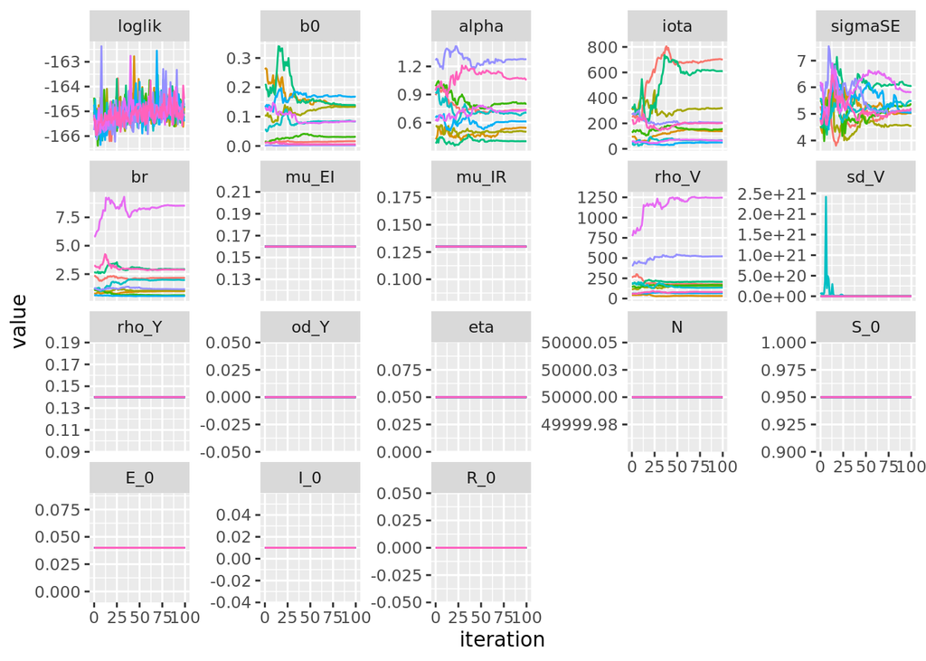

```r
#- Below is the code for the local search

# registerDoRNG(482947940)
# bake(file=paste(cache_address,"/local_search_simple_VY.rds", sep = ''),{
#   foreach(i=1:covid_Nreps_local,.combine=c, .errorhandling="remove") %dopar% {
#     library(pomp)
#     library(tidyverse)
#     covidSEIRsR %>%
#       mif2(
#         params=params_guess,
#         Np=covid_Np, Nmif=covid_Nmif,
#         cooling.fraction.50=0.5,
#         rw.sd=rw.sd(b0=0.02, alpha=0.02, iota=0.02,
#                     sigmaSE=0.02, br=0.01, mu_EI=0.00, mu_IR=0.00,
#                     S_0=ivp(0.00), E_0=ivp(0.00), I_0=ivp(0.00), R_0=ivp(0.00),
#                     eta=ivp(0.00), rho_V=0.01, rho_Y=0.0, sd_V=0.5, od_Y=0.0)
#       ) %>%
#       mif2(cooling.fraction.50=0.3) %>%
#       mif2(cooling.fraction.50=0.1)
#   } -> mifs_local
#   attr(mifs_local,"ncpu") <- getDoParWorkers()
#   mifs_local
# }) -> mifs_local
# t_loc <- attr(mifs_local,"system.time")
# ncpu_loc <- attr(mifs_local,"ncpu")

#- we just load the result of the local search

githubURL <- ("https://raw.githubusercontent.com/Shakeri-Lab/COVID-SEIR/main/res/local_search_simple_Y.rds")
download.file(githubURL,"local_search_simple_Y.rds")
mifs_local <- readRDS("local_search_simple_Y.rds")

mifs_local[[1]] -> SEIR_Y

#plotting the parallel tasks for the local search}
mifs_local %>%
  traces() %>%
  melt() %>%
  ggplot(aes(x=iteration, y=value, group=L1, color=factor(L1)))+
  geom_line()+
  guides(color=FALSE)+
  facet_wrap(~variable,scales="free_y")
```

# Global Search

We read the results of the global searches.

## SEIR-VY

```r
#- Below is the code for

# set.seed(123456)
# #initial guesses, creating parameter ranges
# runif_design(
#   lower=c(b0=0.0001,  rho_V=100,  sd_V=500,
#           alpha=0.5,  iota=1.0, sigmaSE=0.4, br=1.0),
#   upper=c(b0=1.0000,  rho_V=300, sd_V=3000,
#           alpha=1.5,  iota=20., sigmaSE=2, br=20.),
#   nseq=1000
# ) -> guesses
#
# mf1 <- mifs_local[[1]]
#
# fixed_params <- c(N=50000, mu_EI=.16, mu_IR=0.13, rho_Y=0.14, S_0=.95, E_0=.04, I_0=.01, R_0=.0, eta=0.05, od_Y=0)
#
# #run global search}
# bake(file=paste(cache_address,"/global_search_simple_VY_$m.rds", sep = ''),{
#   registerDoRNG(1270401374)
#   foreach(guess=iter(guesses,"row"), .combine=rbind, .errorhandling="remove") %dopar% {
#     library(pomp)
#     library(tidyverse)
#     mf1 %>%
#       mif2(params=c(unlist(guess),fixed_params),
#            Np=covid_Np, Nmif=covid_Nmif,
#            cooling.fraction.50=0.5,
#            rw.sd=rw.sd(b0=0.02, alpha=0.02, iota=0.02,
#                        sigmaSE=0.02, br=0.01, mu_EI=0.00, mu_IR=0.00,
#                        S_0=ivp(0.00), E_0=ivp(0.00), I_0=ivp(0.00), R_0=ivp(0.00),
#                        eta=ivp(0.00), rho_V=0.01, rho_Y=0.0, sd_V=0.5, od_Y=0.0)) %>%
#       mif2(cooling.fraction.50=0.3) %>%
#       mif2() %>%
#       mif2(cooling.fraction.50=0.1) %>%
#       mif2() -> mf
#     replicate(
#       covid_Nreps_global,
#       mf %>% pfilter(Np=covid_Np) %>% logLik()
#     ) %>%
#       logmeanexp(se=TRUE) -> ll
#     mf %>% coef() %>% bind_rows() %>%
#       bind_cols(loglik=ll[1],loglik.se=ll[2])
#   } -> results
#   attr(results,"ncpu") <- getDoParWorkers()
#   results
# }) %>%
#   filter(is.finite(loglik)) -> results
# t_global <- attr(results,"system.time")
# t_gncpu_global <- attr(results,"ncpu")

#- We just load the results of the global search

read_csv("https://raw.githubusercontent.com/Shakeri-Lab/COVID-SEIR/main/res/covid_params_simple_VY.csv") %>%
  filter(is.finite(loglik)) %>%
  select(-X1) %>%
  arrange(-loglik) %>%
  unique() -> res_VY
```

## SEIR-V

```r
#- Below is the code for

# set.seed(123456)
# #initial guesses, creating parameter ranges
# runif_design(
#   lower=c(b0=0.0001,  rho_V=100,  sd_V=500,
#           alpha=0.5,  iota=1.0, sigmaSE=0.4, br=1.0),
#   upper=c(b0=1.0000,  rho_V=300, sd_V=3000,
#           alpha=1.5,  iota=20., sigmaSE=2, br=20.),
#   nseq=1000
# ) -> guesses
#
# mf1 <- mifs_local[[1]]
#
# fixed_params <- c(N=50000, mu_EI=.16, mu_IR=0.13, rho_Y=0.14, S_0=.95, E_0=.04, I_0=.01, R_0=.0, eta=0.05, od_Y=0)
#
# #run global search}
# bake(file=paste(cache_address,"/global_search_simple_VY_$m.rds", sep = ''),{
#   registerDoRNG(1270401374)
#   foreach(guess=iter(guesses,"row"), .combine=rbind, .errorhandling="remove") %dopar% {
#     library(pomp)
#     library(tidyverse)
#     mf1 %>%
#       mif2(params=c(unlist(guess),fixed_params),
#            Np=covid_Np, Nmif=covid_Nmif,
#            cooling.fraction.50=0.5,
#            rw.sd=rw.sd(b0=0.02, alpha=0.02, iota=0.02,
#                        sigmaSE=0.02, br=0.01, mu_EI=0.00, mu_IR=0.00,
#                        S_0=ivp(0.00), E_0=ivp(0.00), I_0=ivp(0.00), R_0=ivp(0.00),
#                        eta=ivp(0.00), rho_V=0.01, rho_Y=0.0, sd_V=0.5, od_Y=0.0)) %>%
#       mif2(cooling.fraction.50=0.3) %>%
#       mif2() %>%
#       mif2(cooling.fraction.50=0.1) %>%
#       mif2() -> mf
#     replicate(
#       covid_Nreps_global,
#       mf %>% pfilter(Np=covid_Np) %>% logLik()
#     ) %>%
#       logmeanexp(se=TRUE) -> ll
#     mf %>% coef() %>% bind_rows() %>%
#       bind_cols(loglik=ll[1],loglik.se=ll[2])
#   } -> results
#   attr(results,"ncpu") <- getDoParWorkers()
#   results
# }) %>%
#   filter(is.finite(loglik)) -> results
# t_global <- attr(results,"system.time")
# t_gncpu_global <- attr(results,"ncpu")

#- We just load the results of the global search

read_csv("https://raw.githubusercontent.com/Shakeri-Lab/COVID-SEIR/main/res/covid_params_simple_V.csv") %>%
  filter(is.finite(loglik)) %>%
  select(-X1) %>%
  arrange(-loglik) %>%
  unique() -> res_V
```

## SEIR-Y

```r
#- Below is the code for

# set.seed(123456)
# #initial guesses, creating parameter ranges
# runif_design(
#   lower=c(b0=0.0001,  rho_V=100,  sd_V=500,
#           alpha=0.5,  iota=1.0, sigmaSE=0.4, br=1.0),
#   upper=c(b0=1.0000,  rho_V=300, sd_V=3000,
#           alpha=1.5,  iota=20., sigmaSE=2, br=20.),
#   nseq=1000
# ) -> guesses
#
# mf1 <- mifs_local[[1]]
#
# fixed_params <- c(N=50000, mu_EI=.16, mu_IR=0.13, rho_Y=0.14, S_0=.95, E_0=.04, I_0=.01, R_0=.0, eta=0.05, od_Y=0)
#
# #run global search}
# bake(file=paste(cache_address,"/global_search_simple_VY_$m.rds", sep = ''),{
#   registerDoRNG(1270401374)
#   foreach(guess=iter(guesses,"row"), .combine=rbind, .errorhandling="remove") %dopar% {
#     library(pomp)
#     library(tidyverse)
#     mf1 %>%
#       mif2(params=c(unlist(guess),fixed_params),
#            Np=covid_Np, Nmif=covid_Nmif,
#            cooling.fraction.50=0.5,
#            rw.sd=rw.sd(b0=0.02, alpha=0.02, iota=0.02,
#                        sigmaSE=0.02, br=0.01, mu_EI=0.00, mu_IR=0.00,
#                        S_0=ivp(0.00), E_0=ivp(0.00), I_0=ivp(0.00), R_0=ivp(0.00),
#                        eta=ivp(0.00), rho_V=0.01, rho_Y=0.0, sd_V=0.5, od_Y=0.0)) %>%
#       mif2(cooling.fraction.50=0.3) %>%
#       mif2() %>%
#       mif2(cooling.fraction.50=0.1) %>%
#       mif2() -> mf
#     replicate(
#       covid_Nreps_global,
#       mf %>% pfilter(Np=covid_Np) %>% logLik()
#     ) %>%
#       logmeanexp(se=TRUE) -> ll
#     mf %>% coef() %>% bind_rows() %>%
#       bind_cols(loglik=ll[1],loglik.se=ll[2])
#   } -> results
#   attr(results,"ncpu") <- getDoParWorkers()
#   results
# }) %>%
#   filter(is.finite(loglik)) -> results
# t_global <- attr(results,"system.time")
# t_gncpu_global <- attr(results,"ncpu")

#- We just load the results of the global search

read_csv("https://raw.githubusercontent.com/Shakeri-Lab/COVID-SEIR/main/res/covid_params_simple_Y.csv") %>%
  filter(is.finite(loglik)) %>%
  select(-X1) %>%
  arrange(-loglik) %>%
  unique() -> res_Y
```

# Results

We can check out all of the parameters explored...

## SEIR-VY

```r
pairs(~loglik+b0+alpha+iota+br+rho_V+sd_V, data=res_VY, pch=16)
```

[output not shown]

## SEIR-V

```r
pairs(~loglik+b0+alpha+iota+br+sigmaSE, data=res_V, pch=16)
```

[output not shown]

## SEIR-Y

```r
pairs(~loglik+b0+alpha+iota+br+sigmaSE, data=res_Y, pch=16)
```

[output not shown]

# Poorman's profiles

We can plot the poorman's profile for different parameters to get a sense of the MLE values for the parameters. We showed the poorman's profile for three of the parameters, $\sigma_{SE}$, $\alpha$, and $\beta_0$ for the three models. One can investigate the other parameters too.

## SEIR-VY

### $\sigma_{SE}$

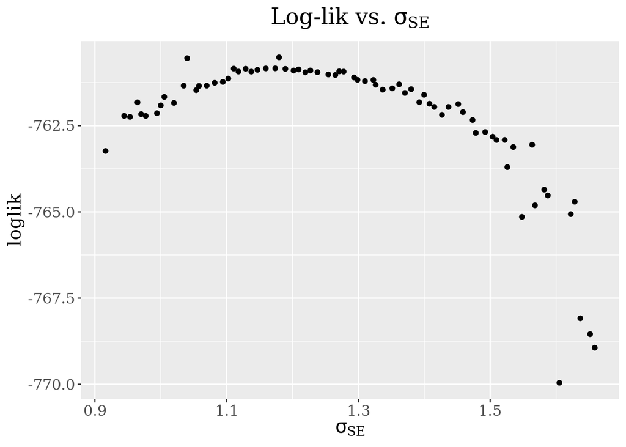

```r
res_VY %>%
  filter(loglik > max(loglik)-10) %>%
  group_by(cut=round(sigmaSE,2)) %>%
  filter(rank(-loglik)<2) %>%
  ggplot(aes(x=sigmaSE, y=loglik)) +
  geom_point()+
  labs(title = TeX('Log-lik vs.$\\sigma_{SE}$'), x=TeX('$\\sigma_{SE}$')) +
  theme(plot.title = element_text(size=18, face="bold", family="Times New Roman", hjust = 0.5),
        axis.title.x = element_text(size = 15, family = "Times New Roman"),
        axis.title.y = element_text(size = 15, family = "Times New Roman"),
        axis.text = element_text( size = 12, family = "Times New Roman"),
        legend.text = element_text(size = 10, family = "Times New Roman"),
        legend.title = element_blank())
```

### $\alpha$

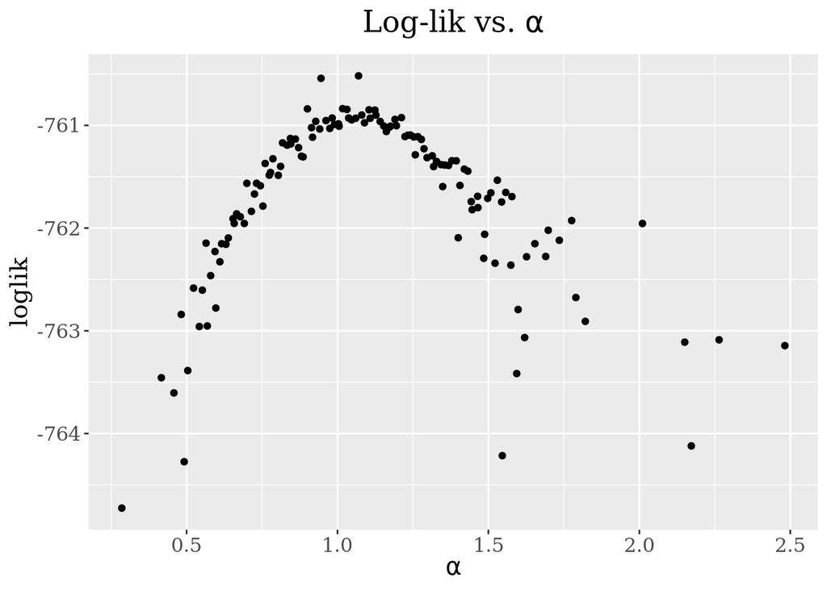

```r
res_VY %>%
  filter(loglik > max(loglik)-5) %>%
  group_by(cut=round(alpha,2)) %>%
  filter(rank(-loglik)<2) %>%
  ggplot(aes(x=alpha, y=loglik)) +
  geom_point()+
  labs(title = TeX('Log-lik vs.$\\alpha$'), x=TeX('$\\alpha$')) +
  theme(plot.title = element_text(size=18, face="bold", family="Times New Roman", hjust = 0.5),
        axis.title.x = element_text(size = 15, family = "Times New Roman"),
        axis.title.y = element_text(size = 15, family = "Times New Roman"),
        axis.text = element_text( size = 12, family = "Times New Roman"),
        legend.text = element_text(size = 10, family = "Times New Roman"),
        legend.title = element_blank())
```

### $\beta_0$

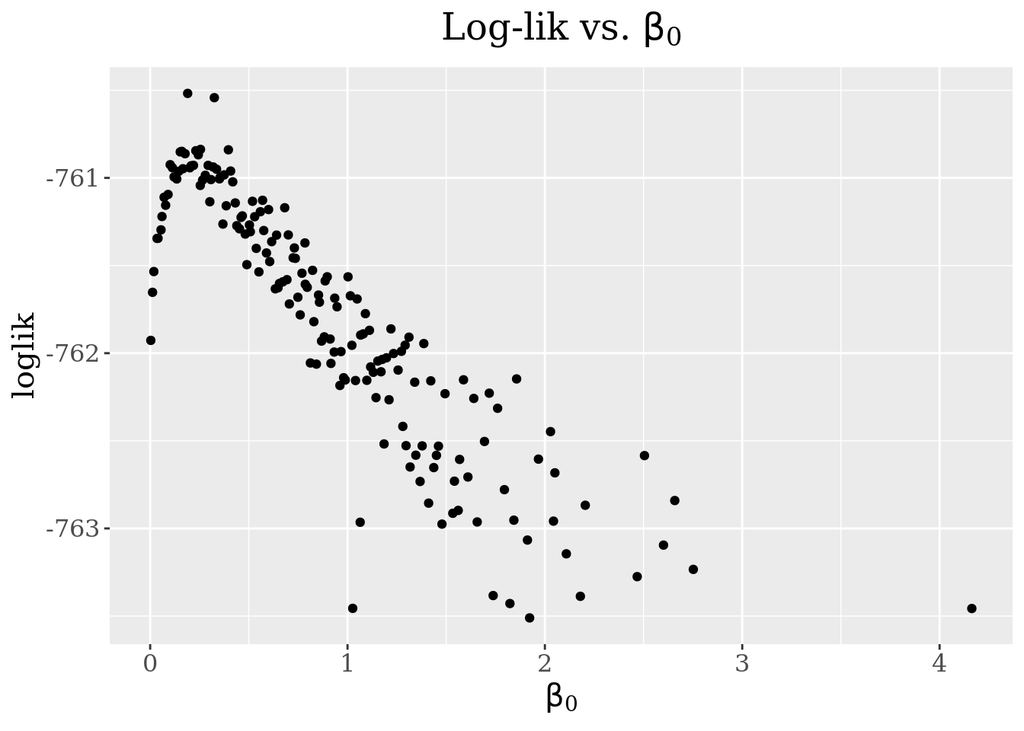

```r
res_VY %>%
  filter(loglik > max(loglik)-3) %>%
  group_by(cut=round(b0,2)) %>%
  filter(rank(-loglik)<2) %>%
  ggplot(aes(x=b0, y=loglik)) +
  geom_point()+
  labs(title = TeX('Log-lik vs.$\\beta_0$'), x=TeX('$\\beta_0$')) +
  theme(plot.title = element_text(size=18, face="bold", family="Times New Roman", hjust = 0.5),
        axis.title.x = element_text(size = 15, family = "Times New Roman"),
        axis.title.y = element_text(size = 15, family = "Times New Roman"),
        axis.text = element_text( size = 12, family = "Times New Roman"),
        legend.text = element_text(size = 10, family = "Times New Roman"),
        legend.title = element_blank())
```

## SEIR-V

### $\sigma_{SE}$

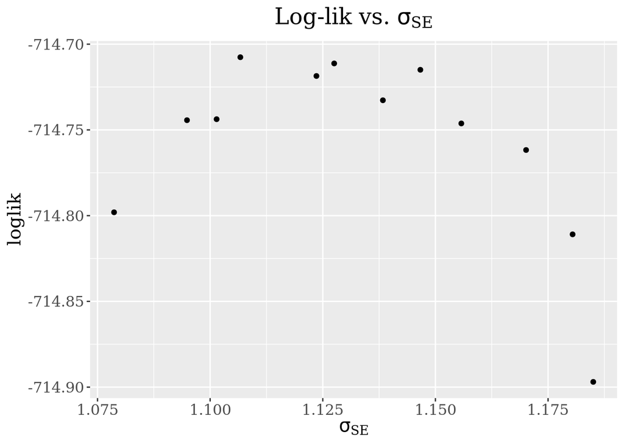

```r
res_V %>%
  filter(loglik > max(loglik)-10) %>%
  group_by(cut=round(sigmaSE,2)) %>%
  filter(rank(-loglik)<2) %>%
  ggplot(aes(x=sigmaSE, y=loglik)) +
  geom_point()+
  labs(title = TeX('Log-lik vs.$\\sigma_{SE}$'), x=TeX('$\\sigma_{SE}$')) +
  theme(plot.title = element_text(size=18, face="bold", family="Times New Roman", hjust = 0.5),
        axis.title.x = element_text(size = 15, family = "Times New Roman"),
        axis.title.y = element_text(size = 15, family = "Times New Roman"),
        axis.text = element_text( size = 12, family = "Times New Roman"),
        legend.text = element_text(size = 10, family = "Times New Roman"),
        legend.title = element_blank())
```

### $\alpha$

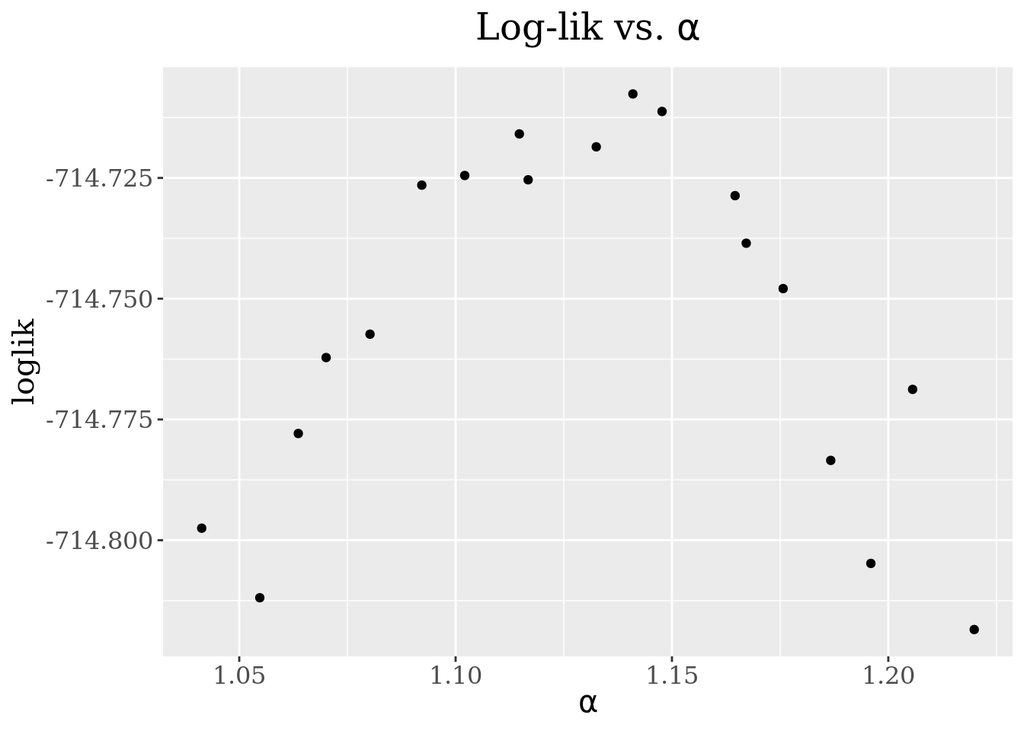

```r
res_V %>%
  filter(loglik > max(loglik)-5) %>%
  group_by(cut=round(alpha,2)) %>%
  filter(rank(-loglik)<2) %>%
  ggplot(aes(x=alpha, y=loglik)) +
  geom_point()+
  labs(title = TeX('Log-lik vs.$\\alpha$'), x=TeX('$\\alpha$')) +
  theme(plot.title = element_text(size=18, face="bold", family="Times New Roman", hjust = 0.5),
        axis.title.x = element_text(size = 15, family = "Times New Roman"),
        axis.title.y = element_text(size = 15, family = "Times New Roman"),
        axis.text = element_text( size = 12, family = "Times New Roman"),
        legend.text = element_text(size = 10, family = "Times New Roman"),
        legend.title = element_blank())
```

### $\beta_0$

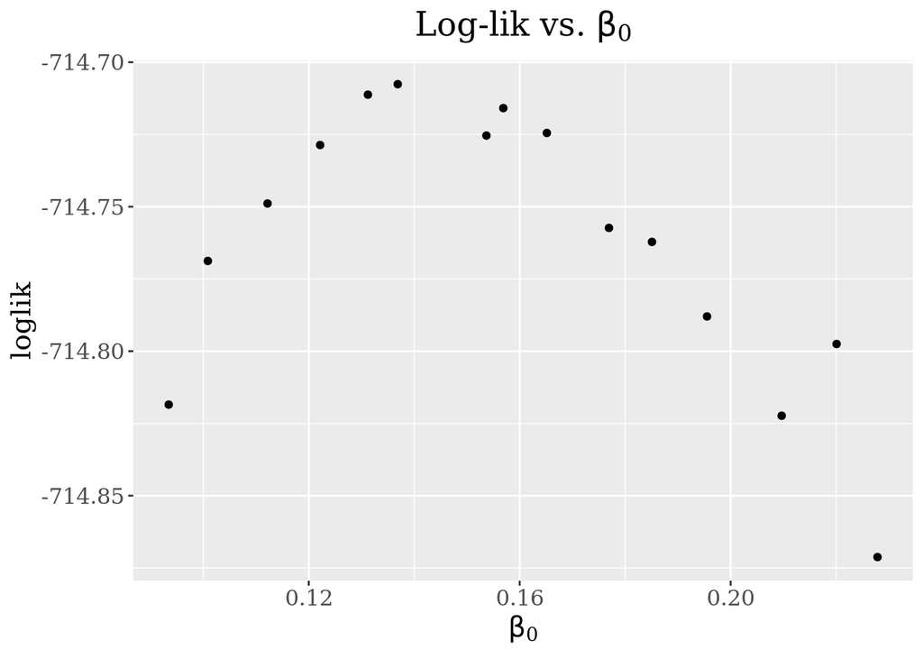

```r
res_V %>%
  filter(loglik > max(loglik)-3) %>%
  group_by(cut=round(b0,2)) %>%
  filter(rank(-loglik)<2) %>%
  ggplot(aes(x=b0, y=loglik)) +
  geom_point()+
  labs(title = TeX('Log-lik vs.$\\beta_0$'), x=TeX('$\\beta_0$')) +
  theme(plot.title = element_text(size=18, face="bold", family="Times New Roman", hjust = 0.5),
        axis.title.x = element_text(size = 15, family = "Times New Roman"),
        axis.title.y = element_text(size = 15, family = "Times New Roman"),
        axis.text = element_text( size = 12, family = "Times New Roman"),
        legend.text = element_text(size = 10, family = "Times New Roman"),
        legend.title = element_blank())
```

## SEIR-Y

### $\sigma_{SE}$

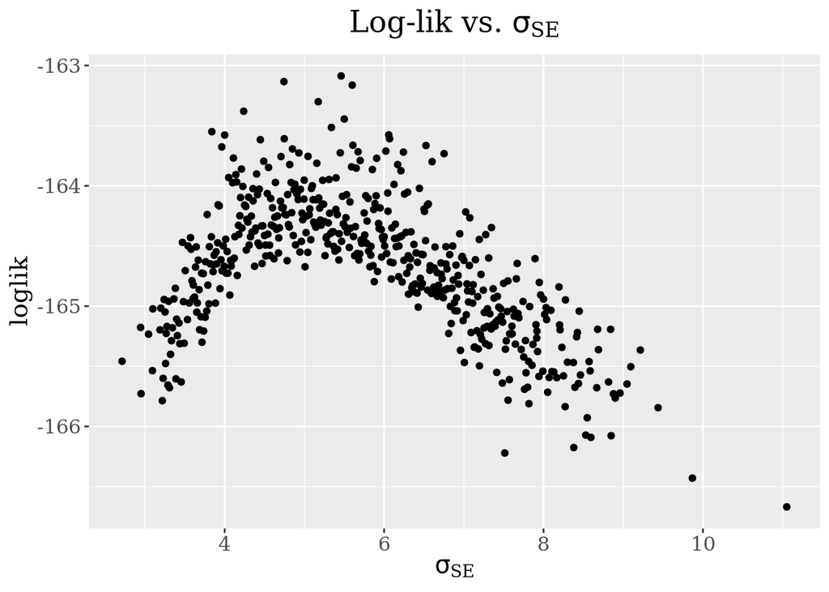

```r
res_Y %>%
  filter(loglik > max(loglik)-10) %>%
  group_by(cut=round(sigmaSE,2)) %>%
  filter(rank(-loglik)<2) %>%
  ggplot(aes(x=sigmaSE, y=loglik)) +
  geom_point()+
  labs(title = TeX('Log-lik vs.$\\sigma_{SE}$'), x=TeX('$\\sigma_{SE}$')) +
  theme(plot.title = element_text(size=18, face="bold", family="Times New Roman", hjust = 0.5),
        axis.title.x = element_text(size = 15, family = "Times New Roman"),
        axis.title.y = element_text(size = 15, family = "Times New Roman"),
        axis.text = element_text( size = 12, family = "Times New Roman"),
        legend.text = element_text(size = 10, family = "Times New Roman"),
        legend.title = element_blank())
```

### $\alpha$

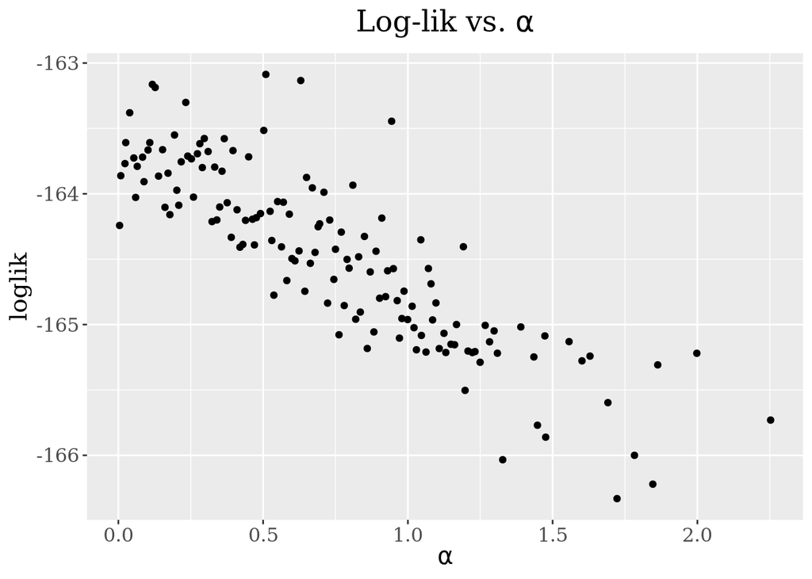

```r
res_Y %>%
  filter(loglik > max(loglik)-5) %>%
  group_by(cut=round(alpha,2)) %>%
  filter(rank(-loglik)<2) %>%
  ggplot(aes(x=alpha, y=loglik)) +
  geom_point()+
  labs(title = TeX('Log-lik vs.$\\alpha$'), x=TeX('$\\alpha$')) +
  theme(plot.title = element_text(size=18, face="bold", family="Times New Roman", hjust = 0.5),
        axis.title.x = element_text(size = 15, family = "Times New Roman"),
        axis.title.y = element_text(size = 15, family = "Times New Roman"),
        axis.text = element_text( size = 12, family = "Times New Roman"),
        legend.text = element_text(size = 10, family = "Times New Roman"),
        legend.title = element_blank())
```

### $\beta_0$

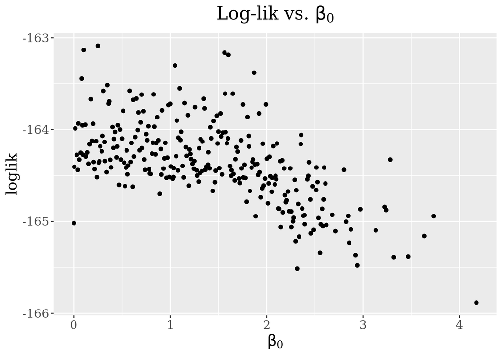

```r
res_Y %>%
  filter(loglik > max(loglik)-3) %>%
  group_by(cut=round(b0,2)) %>%
  filter(rank(-loglik)<2) %>%
  ggplot(aes(x=b0, y=loglik)) +
  geom_point()+
  labs(title = TeX('Log-lik vs.$\\beta_0$'), x=TeX('$\\beta_0$')) +
  theme(plot.title = element_text(size=18, face="bold", family="Times New Roman", hjust = 0.5),
        axis.title.x = element_text(size = 15, family = "Times New Roman"),
        axis.title.y = element_text(size = 15, family = "Times New Roman"),
        axis.text = element_text( size = 12, family = "Times New Roman"),
        legend.text = element_text(size = 10, family = "Times New Roman"),
        legend.title = element_blank())
```

# Simulation comparison

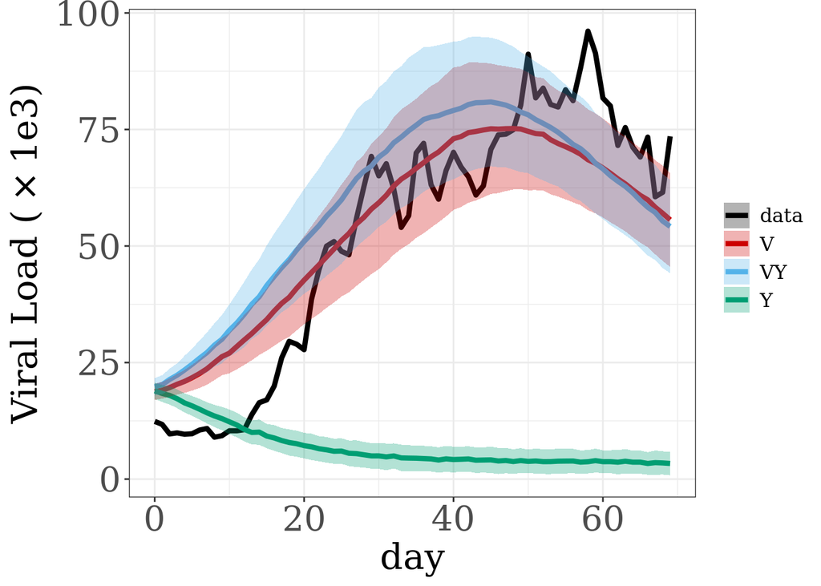

```r
data_cal <- data_c[1:70,]
data_pred <- data_c[70:100,]

res <- bind_rows("V & Y" = res_VY, "V" = res_V, "Y" = res_Y, .id = "type")

res %>%
  filter(type=="V & Y") %>%
  filter(loglik == max(loglik)) %>%
  select(-loglik.se, -loglik, -type) -> params_opt_VY

res %>%
  filter(type=="V") %>%
  filter(loglik == max(loglik)) %>%
  select(-loglik.se, -loglik, -type) -> params_opt_V

res %>%
  filter(type=="Y") %>%
  filter(rank(-loglik)==2) %>%
  select(-loglik.se, -loglik, -type) -> params_opt_Y

params_sim = params_opt_Y
y_Y = SEIR_Y %>%
  simulate(params=params_sim, nsim=1000, format="data.frame")

params_sim = params_opt_V
y_V = SEIR_V %>%
  simulate(params=params_sim, nsim=1000, format="data.frame")

params_sim = params_opt_VY
y_VY = SEIR_VY %>%
  simulate(params=params_sim, nsim=1000, format="data.frame")

y <- bind_rows("VY" = y_VY, "V" = y_V, "Y" = y_Y, .id = "type")

y %>% group_by(day, type) %>% summarize_at(vars(S:R, V, Y), mean) -> y_avg
y %>% group_by(day, type) %>% summarize_at(vars(V, Y), sd) -> y_sd

observed = data_cal %>%
  mutate(actual.cases = Y / 0.14) %>%
  select(day, V = V, Y = actual.cases)


y_avg$V_low <- y_avg$V - 0.5*y_sd$V
y_avg$V_up  <- y_avg$V + 0.5*y_sd$V
y_avg$Y_low <- y_avg$Y - 0.5*y_sd$Y
y_avg$Y_up  <- y_avg$Y + 0.5*y_sd$Y

observed$V_low <- observed$V
observed$V_up  <- observed$V
observed$Y_low <- observed$Y
observed$Y_up  <- observed$Y
observed$type  <- "data"

y_avg <- y_avg %>%
  select(day, type, V, V_low, V_up, Y, Y_low, Y_up)

y_avg <- rbind(y_avg, observed)

y_avg$V_low <- y_avg$V_low/1000
y_avg$V <- y_avg$V/1000
y_avg$V_up <- y_avg$V_up/1000

cbPalette <- c("#000000", "#CC0000", "#56B4E9", "#009E73", "#0072B2", "#D55E00", "#E69F00")

y_avg %>%
  group_by(type) %>%
  ggplot(aes(x = day, y = V)) +
  geom_line(aes(color = type), size=1.5) +
  geom_ribbon(aes(ymin=V_low, ymax=V_up, fill = type), alpha = 0.3)+
  # geom_line(data = observed, aes(x=day, y=V),
  #           color="black", size=1.5, show.legend = c("data")) +
  scale_color_manual(values=cbPalette) +
  scale_fill_manual(values=cbPalette)+
  labs(y=TeX('Viral Load ($\\times 1e3$)')) +
  theme_bw() +
  theme(plot.title = element_text(size=16, face="bold", family="Times New Roman", hjust = 0.5),
        axis.title.x = element_text(size = 22, family = "Times New Roman"),
        axis.title.y = element_text(size = 22, family = "Times New Roman"),
        axis.text = element_text(size = 21, family = "Times New Roman"),
        legend.text = element_text(size = 12, family = "Times New Roman"),
        legend.title = element_blank())
```

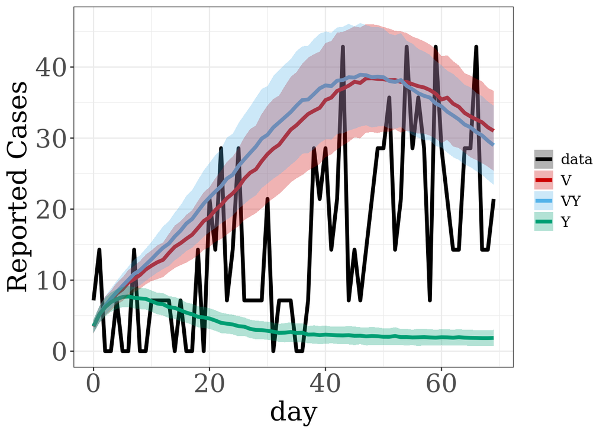

```r
y_avg %>%
  group_by(type) %>%
  ggplot(aes(x = day, y = Y)) +
  geom_line(aes(color = type), size=1.5) +
  geom_ribbon(aes(ymin=Y_low, ymax=Y_up, fill = type), alpha = 0.3)+
  scale_color_manual(values=cbPalette) +
  scale_fill_manual(values=cbPalette)+
  # geom_line(data = observed %>% pivot_wider(names_from = name),
  #           color="black", size=1.5) +
  labs(y="Reported Cases") +
  theme_bw() +
  theme(plot.title = element_text(size=16, face="bold", family="Times New Roman", hjust = 0.5),
        axis.title.x = element_text(size = 22, family = "Times New Roman"),
        axis.title.y = element_text(size = 22, family = "Times New Roman"),
        axis.text = element_text( size = 21, family = "Times New Roman"),
        legend.text = element_text(size = 12, family = "Times New Roman"),
        legend.title = element_blank())
```

# Forecasts

```r
forecast_pomp <- function(h, model, ranges){

  sobol_design(
    lower=ranges[,"min"],
    upper=ranges[,"max"],
    nseq=20
  ) -> params

  library(foreach)
  library(doParallel)
  library(iterators)
  library(doRNG)

  registerDoParallel()
  registerDoRNG(887851050L)

  ## ----forecasts2b----------------------------------------------------------
  foreach(p=iter(params,by="row"),
          .inorder=FALSE,
          .combine=bind_rows
  ) %dopar% {

    library(pomp)

    ## ----forecasts2c----------------------------------------------------------
    M1 <- model

    M1 %>% pfilter(params=p, Np=1000, save.states=TRUE) -> pf

    ## ----forecasts2d----------------------------------------------------------
    pf %>%
      saved.states() %>% ## latent state for each particle
      tail(1) %>%        ## last timepoint only
      melt() %>%         ## reshape and rename the state variables
      spread(variable,value) %>%
      group_by(rep) %>%
      summarize(S_0=S/(S+E+I+R), E_0=E/(S+E+I+R), I_0=I/(S+E+I+R), R_0=R/(S+E+I+R)) %>%
      gather(variable,value,-rep) %>%
      spread(rep,value) %>%
      column_to_rownames("variable") %>%
      as.matrix() -> x

    ## ----forecasts2e1----------------------------------------------------------
    pp <- parmat(unlist(p),ncol(x))

    ## ----forecasts2e2----------------------------------------------------------
    M1 %>%
      simulate(params=pp,format="data.frame") %>%
      select(.id,day,Y, V) %>%
      mutate(
        period="calibration",
        loglik=logLik(pf)
      ) -> calib

    ## ----forecasts2f----------------------------------------------------------
    M2 <- M1
    time(M2) <- max(time(M1))+seq_len(h)
    timezero(M2) <- max(time(M1))

    ## ----forecasts2g----------------------------------------------------------
    pp[rownames(x),] <- x

    M2 %>%
      simulate(params=pp,format="data.frame") %>%
      select(.id,day,Y,V) %>%
      mutate(
        period="projection",
        loglik=logLik(pf)
      ) -> proj

    ## ----forecasts2h----------------------------------------------------------
    bind_rows(calib,proj) -> sims
    return(sims)
  }
}


simq_f <- function(sims){
  sims %>%
    mutate(weight=exp(loglik-mean(loglik))) %>%
    arrange(day,.id) -> sims

  ## ----forecasts2k----------------------------------------------------------
  sims %>%
    filter(day==max(day)) %>%
    summarize(ess=sum(weight)^2/sum(weight^2))

  ## ----forecasts2l----------------------------------------------------------
  sims %>%
    group_by(day,period) %>%
    summarize(
      p=c(0.025,0.5,0.975),
      q=quantile(Y,weights=weight,probs=p),
      label=c("lower","median","upper")
    ) %>%
    select(-p) %>%
    spread(label,q) %>%
    ungroup() %>%
    mutate(date=day) -> simq

  return(simq)
}

##############################

res_VY %>%
  select(-loglik.se) %>%
  filter(loglik>max(loglik)-0.5*qchisq(df=1, p=0.95)) %>%
  gather(parameters,value) %>%
  group_by(parameters) %>%
  summarize(min=min(value),max=max(value)) %>%
  ungroup() %>%
  filter(parameters!="loglik") %>%
  column_to_rownames("parameters") %>%
  as.matrix() -> ranges_VY

res_V %>%
  select(-loglik.se) %>%
  filter(loglik>max(loglik)-0.5*qchisq(df=1, p=0.95)) %>%
  gather(parameters,value) %>%
  group_by(parameters) %>%
  summarize(min=min(value),max=max(value)) %>%
  ungroup() %>%
  filter(parameters!="loglik") %>%
  column_to_rownames("parameters") %>%
  as.matrix() -> ranges_V

res_Y %>%
  select(-loglik.se) %>%
  filter(loglik>max(loglik)-0.5*qchisq(df=1, p=0.95)) %>%
  gather(parameters,value) %>%
  group_by(parameters) %>%
  summarize(min=min(value),max=max(value)) %>%
  ungroup() %>%
  filter(parameters!="loglik") %>%
  column_to_rownames("parameters") %>%
  as.matrix() -> ranges_Y

sims_VY <- forecast_pomp(30, SEIR_VY, ranges_VY)
sims_V <- forecast_pomp(30, SEIR_V, ranges_V)
sims_Y <- forecast_pomp(30, SEIR_Y, ranges_Y)

simq_VY <- simq_f(sims_VY)
simq_V <- simq_f(sims_V)
simq_Y <- simq_f(sims_Y)
simq <- bind_rows("VY" = simq_VY, "V" = simq_V, "Y" = simq_Y, .id = "type") %>%
  filter(period=='projection') %>%
  select(-date)

#-----------------------| ARIMA |------------------------#
library(forecast)
```

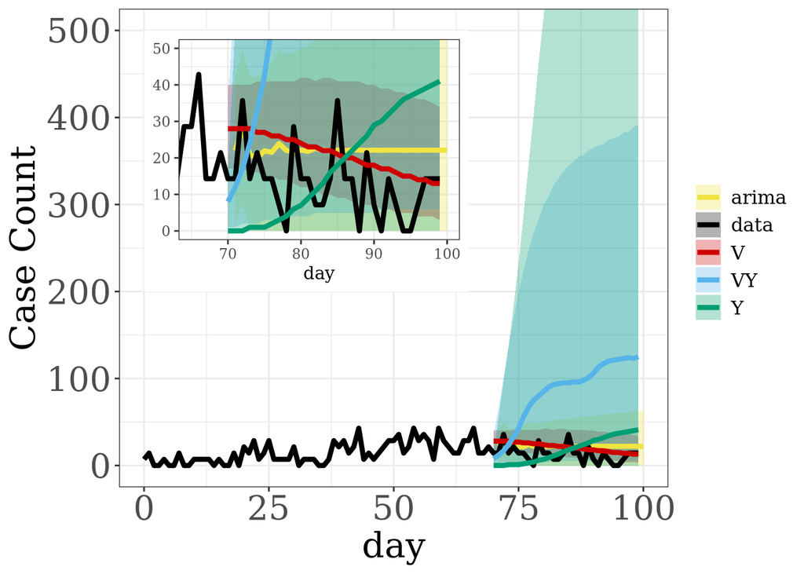

```r
cases <- data_c[1:70,]$Y/0.14
viral <- data_c[1:70,]$V

cases %>% Arima(order=c(4,1,0)) -> arima_case

viral %>% Arima(order=c(1,1,1)) -> arima_viral

case_f_arima <- forecast(arima_case, 30)

data_frame(type='arima', day=71:100, period='projection', lower=case_f_arima$lower[,2], median=case_f_arima$mean,
           upper=case_f_arima$upper[,2]) -> arima_case_f

arima_case_f$lower[3:30] = 0

simq <- bind_rows(simq, arima_case_f)


observed = data_c[1:100,] %>%
  mutate(actual.cases = Y / 0.14) %>%
  select(day, V = V, Y = actual.cases)

observed %>% select(-V) %>%
  mutate(median=Y, lower=Y, upper=Y, period="projection", type="data") %>%
  select(-Y) -> observed

simq <- rbind(simq, observed)
#--------------------------------------------------------#

cbPalette <- c("#F0E442", "#000000","#CC0000", "#56B4E9", "#009E73", "#0072B2", "#D55E00", "#E69F00")

simq %>%
  # filter(type!='Y') %>%
  # filter(type!='VY') %>%
  ggplot(aes(x=day))+
  geom_ribbon(aes(ymin=lower,ymax=upper,fill=type),alpha=0.3,color=NA)+
  geom_line(aes(y=median,color=type), size=1.5)+
  # geom_point(data=observed, mapping=aes(x=day,y=Y),color="black")+
  # geom_line(data=observed, mapping=aes(x=day,y=Y))+
  labs(y="cases") +
  scale_color_manual(values=cbPalette) +
  scale_fill_manual(values=cbPalette)+
    labs(y="Case Count") +
  coord_cartesian(ylim = c(0, 500), xlim = c(0,100)) +
  theme_bw()+
  theme(plot.title = element_text(size=16, face="bold", family="Times New Roman", hjust = 0.5),
        axis.title.x = element_text(size = 22, family = "Times New Roman"),
        axis.title.y = element_text(size = 22, family = "Times New Roman"),
        axis.text = element_text( size = 21, family = "Times New Roman"),
        legend.text = element_text(size = 12, family = "Times New Roman"),
        legend.title = element_blank()) -> p

p.zoom <- ggplot(simq, aes(x=day)) +
  geom_ribbon(aes(ymin=lower,ymax=upper,fill=type),alpha=0.3,color=NA) +
  geom_line(aes(y=median,color=type), size=1.5) +
  scale_color_manual(values=cbPalette) +
  scale_fill_manual(values=cbPalette) +
  coord_cartesian(xlim=c(65,100), ylim=c(0,50)) +
  theme_bw() +
  theme(axis.title.y=element_blank(),
        axis.title.x = element_text(family = "Times New Roman"),
        legend.position = "none",
        axis.text = element_text(family = "Times New Roman"))

p +  annotation_custom(ggplotGrob(p.zoom), xmin = 0, xmax = 65,
                       ymin = 200, ymax = 500)
```